# R6 Seige EDA

Makenzy Gilbert

2023-10-26

# Rainbow Six Siege Exploratory Data Analysis

## Introduction

Rainbow Six Siege is a first-person shooter video game with two teams of five players each. One team acts as the “attackers,” striving to complete objectives such as rescuing hostages or defusing bombs, while the other team serves as the “defenders,” aiming to thwart their efforts. Before each match, players select their “operator,” each of whom possesses a unique gadget or ability that significantly impacts the game’s strategy.

During the match, both teams can ban one attacking and one defending operator, preventing the opposing team from selecting those operators. This operator selection process adds an extra layer of strategy to the game. The rounds are fast-paced, requiring meticulous planning and quick reflexes.

Operators wield firearms with specific recoil patterns, mirroring their real-world counterparts. Some operators share the same primary weapons, resulting in shared recoil patterns. These patterns dictate how a weapon behaves when fired continuously and influence aim deviation. Mastering these recoil patterns enables players to maintain accuracy during intense firefights.

Rainbow Six Siege demands players’ full attention, making sound an integral part of the game. With over 800 unique audio cues to discern, sound cues play a crucial role in gameplay. Additionally, numerous environmental objects offer tactical advantages, requiring players to monitor various angles for opponents. Players can also customize their weapon sights/scopes, further affecting their aiming mechanics. Memorizing maps, room layouts, and operator abilities adds another layer of strategic depth to the game.

Incorporating principles from cognitive load theory, game developers recognize the importance of working memory limitations in instructional design. This theory aligns with Miller’s Law, which suggests that people can hold around 7 (plus or minus 2) items in their working memory. Fitt’s Law, which states that the time to acquire a target depends on its size and distance, also informs game design decisions.

In the context of Rainbow Six Siege, weapons with wider recoil spreads demand more attention and control, aligning with the concept of allocating attentional resources in-game. Game development studios employ seasoned UX/UI researchers to enhance game play by considering cognitive limitations and abilities, making Rainbow Six Siege a strategically engaging and immersive gaming experience.

Research Question: Does higher levels of cognitive strain due to larger spread in recoil patterns (of weapons for operators), influence or correlate with Pick vs. Ban Rates of operators?

# Setup

```r
# Dependencies
library(tidyverse)
library(skimr)
library(rvest)
library(googlesheets4)
gs4_auth()
```

```
## ! Using an auto-discovered, cached token.
##   To suppress this message, modify your code or options to clearly consent to
##   the use of a cached token.
##   See gargle's "Non-interactive auth" vignette for more details:
## ℹ The googlesheets4 package is using a cached token for 'makenzy101@gmail.com'.
```

## Data set

Rvesting the data set:

This data set consists of a table of all weapons used in the game and provides statistics; such as, type of gun, firing rate, and the operator that uses it. The original creators of the game and the publishing company, Ubisoft, are overall the generators for the data I am using. The first data source, IGN, provides information about weapons and equipment in Rainbow Six Siege. IGN is a popular gaming and entertainment website, and they compiled this data to provide a resource for gamers interested in the game’s details.

```r
url <- "https://www.ign.com/wikis/rainbow-six-siege/Weapons_and_Equipment"
page <- read_html(url)
table_data <- page %>%
#   html_nodes("section.jsx-2191675443.jsx-380427680.jsx-28683165.wiki-section.wiki-html table") %>%
  html_table()
my_table <- table_data[[1]]
```

# Check NA’s and Packaging

```r
skim(table_data)
```

Data summary

| Name | table_data |
| --- | --- |
| Number of rows | 100 |
| Number of columns | 11 |
| _______________________ |  |
| Column type frequency: |  |
| character | 10 |
| numeric | 1 |
| ________________________ |  |
| Group variables | None |

**Variable type: character**

| skim_variable | n_missing | complete_rate | min | max | empty | n_unique | whitespace |
| --- | --- | --- | --- | --- | --- | --- | --- |
| Name | 0 | 1 | 2 | 17 | 0 | 100 | 0 |
| Type | 0 | 1 | 3 | 18 | 0 | 8 | 0 |
| Operator | 0 | 1 | 2 | 29 | 0 | 69 | 0 |
| Team | 0 | 1 | 8 | 16 | 0 | 3 | 0 |
| CTU | 0 | 1 | 3 | 23 | 0 | 29 | 0 |
| Damage..Suppressed.. | 0 | 1 | 2 | 7 | 0 | 50 | 0 |
| ROF | 0 | 1 | 3 | 9 | 0 | 33 | 0 |
| Suppressor | 0 | 1 | 1 | 2 | 0 | 3 | 0 |
| ACOG | 0 | 1 | 1 | 2 | 0 | 3 | 0 |
| Var.11 | 0 | 1 | 9 | 19 | 0 | 7 | 0 |

**Variable type: numeric**

| skim_variable | n_missing | complete_rate | mean | sd | p0 | p25 | p50 | p75 | p100 | hist |
| --- | --- | --- | --- | --- | --- | --- | --- | --- | --- | --- |
| Magazine | 0 | 1 | 25.28 | 22.17 | 2 | 10 | 20 | 30 | 150 | ▇▁▁▁▁ |

There is one column missing a name

Remove/Replace NA in column names:

```r
 View(my_table)
 colnames(my_table)
```

```
##  [1] "Name"                 "Type"                 "Operator"
##  [4] "Team"                 "CTU"                  "Damage (Suppressed*)"
##  [7] "ROF"                  "Magazine"             "Suppressor"
## [10] "ACOG"                 ""
```

```r
# [1] "Name"                 "Type"                 "Operator"
# [4] "Team"                 "CTU"                  "Damage (Suppressed*)"
# [7] "ROF"                  "Magazine"             "Suppressor"
# [10] "ACOG"                 ""

colnames(my_table)[11] <- "Range"
```

Next I need to rename “Name” column to be more descriptive:

```r
my_table<- my_table %>%
  rename(Weapon = Name)
```

```r
# View the result
print(my_table)
```

```
## # A tibble: 100 × 11
##    Weapon       Type  Operator Team  CTU   `Damage (Suppressed*)` ROF   Magazine
##    <chr>        <chr> <chr>    <chr> <chr> <chr>                  <chr>    <int>
##  1 L85A2        Assa… SledgeT… Atta… SAS   47 (39)                670         30
##  2 AR33         Assa… Thatcher Atta… SAS   41 (34)                749         25
##  3 G36C         Assa… Ash      Atta… FBI   38 (32)                780         30
##  4 R4-C         Assa… Ash      Atta… FBI   39 (33)                860         30
##  5 556xi        Assa… Thermite Atta… FBI   46 (39)                690         30
##  6 F2           Assa… Twitch   Atta… GIGN  37 (31)                980         30
##  7 AK-12        Assa… Fuze     Atta… Spet… 45 (38)                850         30
##  8 AUG A2       Assa… IQ       Atta… GSG9  42 (35)                720         30
##  9 552 Commando Assa… IQ       Atta… GSG9  48 (40)                490         30
## 10 416-C Carbi… Assa… Jäger    Defe… GSG9  43 (36)                740         30
## # ℹ 90 more rows
## # ℹ 3 more variables: Suppressor <chr>, ACOG <chr>, Range <chr>
```

The next packaging issue is the concatenated “overlapping” of operators per each weapon. I need to split these.

```r
# # Splitting the operator column based on uppercase letters
# # Split the Operator column and unnest the result
# my_table_split <- my_table %>%
#   # Use str_extract_all to find all uppercase followed by lowercase strings (operators' names)
#   mutate(Operator = str_extract_all(Operator, "[A-Z][a-z]+")) %>%
#   # Unnest the list column to separate rows
#   unnest(Operator)
#
# # View the result
# print(my_table_split)
# view(my_table_split)
#
# ## There's a major issue missing IQ LOL because its two uppercase letters


# Splitting the operator column based on uppercase letters
# Split the Operator column and unnest the result
my_table_split <- my_table %>%
  # Use str_extract_all to find all uppercase followed by lowercase strings (operators' names)
  # or all uppercase strings with 2 or more characters
  mutate(Operator = str_extract_all(Operator, "([A-Z][a-z]+|[A-Z]{2,})")) %>%
  # Unnest the list column to separate rows
  unnest(Operator)

# View the result
print(my_table_split)
```

```
## # A tibble: 167 × 11
##    Weapon       Type  Operator Team  CTU   `Damage (Suppressed*)` ROF   Magazine
##    <chr>        <chr> <chr>    <chr> <chr> <chr>                  <chr>    <int>
##  1 L85A2        Assa… Sledge   Atta… SAS   47 (39)                670         30
##  2 L85A2        Assa… Thatcher Atta… SAS   47 (39)                670         30
##  3 AR33         Assa… Thatcher Atta… SAS   41 (34)                749         25
##  4 G36C         Assa… Ash      Atta… FBI   38 (32)                780         30
##  5 R4-C         Assa… Ash      Atta… FBI   39 (33)                860         30
##  6 556xi        Assa… Thermite Atta… FBI   46 (39)                690         30
##  7 F2           Assa… Twitch   Atta… GIGN  37 (31)                980         30
##  8 AK-12        Assa… Fuze     Atta… Spet… 45 (38)                850         30
##  9 AUG A2       Assa… IQ       Atta… GSG9  42 (35)                720         30
## 10 552 Commando Assa… IQ       Atta… GSG9  48 (40)                490         30
## # ℹ 157 more rows
## # ℹ 3 more variables: Suppressor <chr>, ACOG <chr>, Range <chr>
```

# Data Source 2

The second main data source, Gameriv, offers pick and ban rates for operators in Rainbow Six Siege. Gameriv is a gaming-focused website, and they collected this data to inform the gaming community about the popularity and ban rates of operators in the game. (Graphs were collected straight from Ubisoft's seasonal data roundup.) The exact data was collected from seasonal statistics of gameplay from year 7 early few seasons 1.2-3. released March of 2022 and data from the designer's notes officially was published on Ubisoft's website 4/5/2022. The Gameriv review article was published September 12, 2022.

From Source: “Credit: All the graphs below have been collected from Ubisoft and contain data recorded from PCRanked Platinum and above.” This is helpful to note that the data comes from players using only a personal computer in high level ranked games, as opposed to console players being included.

These ranks are also important to note. Overall, the player base that the data stems from is ranked by these ranks: (worst to best).

• Copper V, IV, III, II, I • Bronze V, IV, III, II, I • Silver V, IV, III, II, I • Gold V, IV, III, II, I • Platinum V, IV, III, II, I • Emerald V, IV, III, II, I • Diamond V, IV, III, II, I • Champions

Data comes from the upper echelon of skilled players. It is the top half of all ranked players that provide this data. It is a set of extremely knowledgeable and experienced players.

High pick, average pick, and low pick rates have been determined by a metric as follows:

Attackers: High Pick Rate (Presence > 40%) Average Pick Rate (15% < Presence < 40%) Low Pick Rate (Presence < 15%)

Defenders: High Pick Rate (Presence > 30%) Average Pick Rate (18% < Presence < 30%) Low Pick Rate (Presence < 10%)

## Add pick rate column

```r
high_pick <- c("Finka", "Iana", "Sledge", "Thatcher", "Twitch", "Alibi", "Jager", "Melusi", "Mute")
average_pick <- c("Valkyrie", "Thunderbird", "Smoke", "Bandit", "Kaid", "Wamai", "Mozzie", "Azami", "Lesion", "Kapkan", "Aruni", "Oryx", "Jackal", "Ace", "Thermite", "Zofia", "Maverick", "Hibana", "Ash", "Nomad")
low_pick <- c("Buck", "Osa", "Nokk", "Flores", "Amaru", "IQ", "Zero", "Montagne", "Dokkaebi", "Blackbeard", "Lion", "Blitz", "Kali", "Capitao", "Fuze", "Ying", "Gridlock", "Glaz", "Sens", "Vigil", "Doc", "Ela", "Mira", "Goyo", "Frost", "Thorn", "Maestro", "Pulse", "Rook", "Castle", "Clash", "Warden", "Caveira", "Echo", "Tachanka")

my_table_long <- my_table_split %>%
  mutate(PickRate = case_when(
    Operator %in% high_pick ~ "High Pick Rate",
    Operator %in% average_pick ~ "Average Pick Rate",
    Operator %in% low_pick ~ "Low Pick Rate",
    TRUE ~ NA_character_
  ))
```

```r
# View the modified table with the new PickRate column
summary(my_table_long)
```

```
##     Weapon              Type             Operator             Team
##  Length:167         Length:167         Length:167         Length:167
##  Class :character   Class :character   Class :character   Class :character
##  Mode  :character   Mode  :character   Mode  :character   Mode  :character
##
##
##
##      CTU            Damage (Suppressed*)     ROF               Magazine
##  Length:167         Length:167           Length:167         Min.   :  2.00
##  Class :character   Class :character     Class :character   1st Qu.:  8.00
##  Mode  :character   Mode  :character     Mode  :character   Median : 16.00
##                                                             Mean   : 21.17
##                                                             3rd Qu.: 30.00
##                                                             Max.   :150.00
##   Suppressor            ACOG              Range             PickRate
##  Length:167         Length:167         Length:167         Length:167
##  Class :character   Class :character   Class :character   Class :character
##  Mode  :character   Mode  :character   Mode  :character   Mode  :character
##
##
##
```

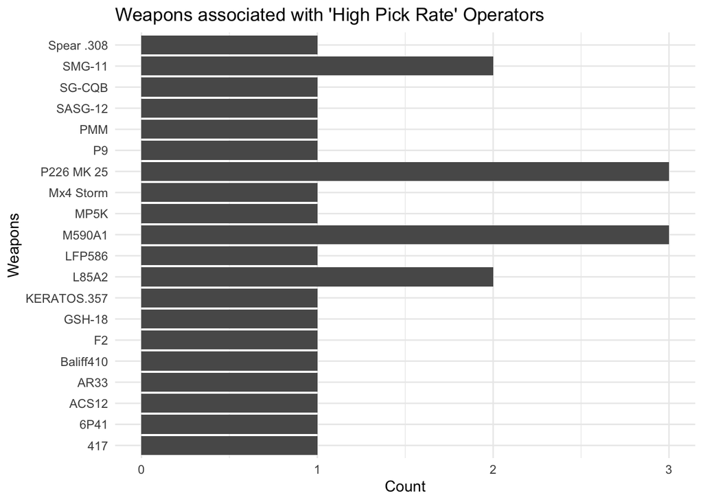

```r
# Filter for High Pick Rate weapons
high_pick_rate_weapons <- my_table_long %>% filter(`PickRate` == 'High Pick Rate')

# Create the ggplot
ggplot(high_pick_rate_weapons, aes(x = Weapon)) +
  geom_bar() +
  coord_flip() +  # Flipping the axis for better visualization
  labs(title = "Weapons associated with 'High Pick Rate' Operators",
       x = "Weapons",
       y = "Count") +
  theme_minimal()
```

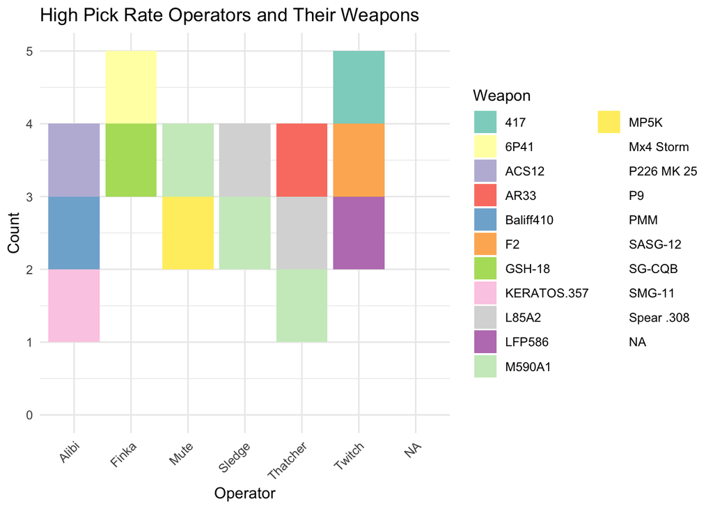

```r
# Filter data for 'High Pick Rate'
high_pick_data <- my_table_long[my_table_long$`PickRate` == "High Pick Rate", ]

# Plot
ggplot(high_pick_data, aes(x = Operator, fill = Weapon)) +
  geom_bar() +
  labs(title = "High Pick Rate Operators and Their Weapons",
       x = "Operator",
       y = "Count") +
  theme_minimal() +
  theme(axis.text.x = element_text(angle = 45, hjust = 1)) +
  scale_fill_brewer(palette = "Set3", name = "Weapon")
```

## Data Source #3

### Recoil statistics

```
    I want to extract column "L" containing the recoil scores, as well as "B" for the associated weapon.
    There are two separate sheets one is attacker and one is for defenders so I will repeat the extraction for both sheets.
```

```r
SCOAR<- "1BxIHO_VHKXuNYypY6NRihik98HJN1b9d0_nZCE_l-ts"

SCOAR_ARECOIL <-googlesheets4::read_sheet(SCOAR, range = "attacker guns!L:L")
```

```
## Auto-refreshing stale OAuth token.
```

```
## ✔ Reading from "Copy of SCOAR: the best guns in Siege, by Dogtor Flashbank".
```

```
## ✔ Range ''attacker guns'!L:L'.
```

```r
SCOAR_AWEAPON <- read_sheet(SCOAR, range = "attacker guns!B:B")
```

```
## ✔ Reading from "Copy of SCOAR: the best guns in Siege, by Dogtor Flashbank".
```

```
## ✔ Range ''attacker guns'!B:B'.
```

```r
# Merge the two columns by row number
atrecoil_data <- cbind(SCOAR_AWEAPON, SCOAR_ARECOIL)

# View the merged data frame
print(atrecoil_data)
```

```
##          Weapon Recoil
## 1         AK-12    0.5
## 2       SC3000K    0.5
## 3            F2    0.0
## 4            M4    0.5
## 5          AR33    1.0
## 6          G8A1    0.0
## 7          T-95    1.0
## 8      PARA-308    1.0
## 9  552 Commando    0.5
## 10         G36C    0.5
## 11         G36C    0.5
## 12        L85A2    1.0
## 13        556XI    0.5
## 14          C7E    0.0
```

[output cut: 23 more lines]

```r
SCOAR<- "1BxIHO_VHKXuNYypY6NRihik98HJN1b9d0_nZCE_l-ts"

SCOAR_DRECOIL <-googlesheets4::read_sheet(SCOAR, range = "defender guns!L:L")
```

```
## ✔ Reading from "Copy of SCOAR: the best guns in Siege, by Dogtor Flashbank".
```

```
## ✔ Range ''defender guns'!L:L'.
```

```r
SCOAR_DWEAPON <- read_sheet(SCOAR, range = "defender guns!B:B")
```

```
## ✔ Reading from "Copy of SCOAR: the best guns in Siege, by Dogtor Flashbank".
```

```
## ✔ Range ''defender guns'!B:B'.
```

```r
# Merge the two columns by row number
defrecoil_data <- cbind(SCOAR_DWEAPON, SCOAR_DRECOIL)

# View the merged data frame
print(defrecoil_data)
```

```
##               Weapon Recoil
## 1           Alda 556    0.5
## 2                MPX    1.0
## 3          Mx4 Storm    0.5
## 4             T5 SMG    0.5
## 5              FMG-9    0.5
## 6              MP5SD    0.5
## 7            9x19VSN    0.5
## 8                MPX    1.0
## 9             9mm C1    1.0
## 10          P10 RONI    0.5
## 11            AUG A2    0.7
## 12               MP5    0.5
## 13            AUG A3    1.0
## 14            T5 SMG    0.5
```

[output cut: 20 more lines]

```r
## TODO I need to make sure these two dataframes get combined to one larger df, then zip weapon col from this df and my long table so that each weapon has a score

## Need to talk about the metrics for ratings. Start a prezzi

combo_recoil <- rbind(defrecoil_data, atrecoil_data)

## interesting 71 obs... still some missing,
```

SO now I need to add this into my og dataframe. But first… what are the missing guns besides the handguns? is that fit for my research still? Alright it comes down to spelling errors omG